# Project: GapMinder

## Investigating 4 key indices across all the countries of the world

## 1. Introduction

GapMinder is a dataset compiled by the GapMinder foundation that tracks key indices (like population, GDP etc.) across different countries of the world. In this dataset I am investigating 4 key indices- life expectancy, GDP per capita, child mortality and fertility across 193 different countries of the world. The data is compiled from 1800-2018.

**Index explaination**  
1) Life expectancy is the average life in years of all the people in that country. An epidemic or a war can cause more deaths and reduce this statistic.  
2) GDP per capita is the gross domestic product / population of the nation in US dollars.  
3) Child mortality is number of deaths / 1000 births in a country.  
4) Fertility rate is number of births per woman in a country.

In this project I will be analyzing the following-  
1) World wide trend for all 4 key indices since 1800 to 2018.  
2) Exploring any unsual trends in the 4 indices over time.  
3) Exploring if there is any correlation between the 4 indices.  
4) Finding which countries performed best in each index and comparing them with major world economies- USA and China.  
5) Visualizing the GDP of major economies for comparison.

For this project I have used **Numpy, Pandas, Matplotlib** and **Seaborn** libraries.

```python
import numpy as np
import pandas as pd
import matplotlib.pyplot as plt
import seaborn as sns

%matplotlib inline
```

## 2. Data Wrangling

### 2.1 Loading Dataset

Each dataset for the 4 indices were downloaded from the [GapMinder website](https://www.gapminder.org/data/) in a csv format. Below all the 4 csv files are uploaded from the local drive using Pandas.

Following code uploads life expectancy dataset.

```python
# Uploading the dataset for Life Expectancy

life_exp= pd.read_csv(r'C:\Users\srini\OneDrive\Documents\Udacity\life_expectancy_years.csv')
life_exp.head(2)

life_exp.info()
```

```
<class 'pandas.core.frame.DataFrame'>
RangeIndex: 187 entries, 0 to 186
Columns: 220 entries, country to 2018
dtypes: float64(219), object(1)
memory usage: 321.5+ KB
```

Following code uploads GDP per capita dataset.

```python
# Uploading the dataset for GDP per capita

gdp= pd.read_csv(r'C:\Users\srini\OneDrive\Documents\Udacity\income_per_person_gdppercapita_ppp_inflation_adjusted.csv')
gdp.info()
gdp.head(2)
```

```
<class 'pandas.core.frame.DataFrame'>
RangeIndex: 193 entries, 0 to 192
Columns: 242 entries, country to 2040
dtypes: int64(241), object(1)
memory usage: 365.0+ KB
```

|  | country | 1800 | 1801 | 1802 | 1803 | 1804 | 1805 | 1806 | 1807 | 1808 | ... | 2031 | 2032 | 2033 | 2034 | 2035 | 2036 | 2037 | 2038 | 2039 | 2040 |
| --- | --- | --- | --- | --- | --- | --- | --- | --- | --- | --- | --- | --- | --- | --- | --- | --- | --- | --- | --- | --- | --- |
| 0 | Afghanistan | 603 | 603 | 603 | 603 | 603 | 603 | 603 | 603 | 603 | ... | 2420 | 2470 | 2520 | 2580 | 2640 | 2700 | 2760 | 2820 | 2880 | 2940 |
| 1 | Albania | 667 | 667 | 667 | 667 | 667 | 668 | 668 | 668 | 668 | ... | 18500 | 18900 | 19300 | 19700 | 20200 | 20600 | 21100 | 21500 | 22000 | 22500 |

2 rows × 242 columns

Following code uploads fertility dataset

```python
# Uploading the dataset for fertility

fertility= pd.read_csv(r'C:\Users\srini\OneDrive\Documents\Udacity\children_per_woman_total_fertility.csv')
fertility.info()
fertility.head()
```

```
<class 'pandas.core.frame.DataFrame'>
RangeIndex: 184 entries, 0 to 183
Columns: 220 entries, country to 2018
dtypes: float64(219), object(1)
memory usage: 316.4+ KB
```

|  | country | 1800 | 1801 | 1802 | 1803 | 1804 | 1805 | 1806 | 1807 | 1808 | ... | 2009 | 2010 | 2011 | 2012 | 2013 | 2014 | 2015 | 2016 | 2017 | 2018 |
| --- | --- | --- | --- | --- | --- | --- | --- | --- | --- | --- | --- | --- | --- | --- | --- | --- | --- | --- | --- | --- | --- |
| 0 | Afghanistan | 7.00 | 7.00 | 7.00 | 7.00 | 7.00 | 7.00 | 7.00 | 7.00 | 7.00 | ... | 6.04 | 5.82 | 5.60 | 5.38 | 5.17 | 4.98 | 4.80 | 4.64 | 4.48 | 4.33 |
| 1 | Albania | 4.60 | 4.60 | 4.60 | 4.60 | 4.60 | 4.60 | 4.60 | 4.60 | 4.60 | ... | 1.65 | 1.65 | 1.67 | 1.69 | 1.70 | 1.71 | 1.71 | 1.71 | 1.71 | 1.71 |
| 2 | Algeria | 6.99 | 6.99 | 6.99 | 6.99 | 6.99 | 6.99 | 6.99 | 6.99 | 6.99 | ... | 2.83 | 2.89 | 2.93 | 2.94 | 2.92 | 2.89 | 2.84 | 2.78 | 2.71 | 2.64 |
| 3 | Angola | 6.93 | 6.93 | 6.93 | 6.93 | 6.93 | 6.93 | 6.93 | 6.94 | 6.94 | ... | 6.24 | 6.16 | 6.08 | 6.00 | 5.92 | 5.84 | 5.77 | 5.69 | 5.62 | 5.55 |
| 4 | Antigua and Barbuda | 5.00 | 5.00 | 4.99 | 4.99 | 4.99 | 4.98 | 4.98 | 4.97 | 4.97 | ... | 2.15 | 2.13 | 2.12 | 2.10 | 2.09 | 2.08 | 2.06 | 2.05 | 2.04 | 2.03 |

5 rows × 220 columns

Following code uploads child mortality dataset

```python
# Uploading the dataset for Child Mortality

child_m= pd.read_csv(r'C:\Users\srini\OneDrive\Documents\Udacity\child_mortality_0_5_year_olds_dying_per_1000_born.csv')
child_m.info()
child_m.head()
```

```
<class 'pandas.core.frame.DataFrame'>
RangeIndex: 193 entries, 0 to 192
Columns: 220 entries, country to 2018
dtypes: float64(219), object(1)
memory usage: 331.8+ KB
```

|  | country | 1800 | 1801 | 1802 | 1803 | 1804 | 1805 | 1806 | 1807 | 1808 | ... | 2009 | 2010 | 2011 | 2012 | 2013 | 2014 | 2015 | 2016 | 2017 | 2018 |
| --- | --- | --- | --- | --- | --- | --- | --- | --- | --- | --- | --- | --- | --- | --- | --- | --- | --- | --- | --- | --- | --- |
| 0 | Afghanistan | 469.0 | 469.0 | 469.0 | 469.0 | 469.0 | 469.0 | 470.0 | 470.0 | 470.0 | ... | 94.1 | 90.2 | 86.4 | 82.8 | 79.3 | 76.1 | 73.2 | 70.4 | 68.2 | 65.9 |
| 1 | Albania | 375.0 | 375.0 | 375.0 | 375.0 | 375.0 | 375.0 | 375.0 | 375.0 | 375.0 | ... | 17.2 | 16.6 | 16.0 | 15.4 | 14.9 | 14.4 | 14.0 | 13.5 | 13.3 | 12.9 |
| 2 | Algeria | 460.0 | 460.0 | 460.0 | 460.0 | 460.0 | 460.0 | 460.0 | 460.0 | 460.0 | ... | 28.3 | 27.3 | 26.6 | 26.1 | 25.8 | 25.6 | 25.5 | 25.2 | 23.9 | 23.1 |
| 3 | Andorra | NaN | NaN | NaN | NaN | NaN | NaN | NaN | NaN | NaN | ... | 3.4 | 3.3 | 3.2 | 3.1 | 3.0 | 2.9 | 2.8 | 2.7 | NaN | NaN |
| 4 | Angola | 486.0 | 486.0 | 486.0 | 486.0 | 486.0 | 486.0 | 486.0 | 486.0 | 486.0 | ... | 128.0 | 119.0 | 111.0 | 104.0 | 96.8 | 91.2 | 86.5 | 82.5 | 83.1 | 81.6 |

5 rows × 220 columns

### 2.2 Exploring missing values

Some countries do not have any indicators present. On exploring they were found to be mostly small countries like Nauru, Tuvalu, Monaco etc that had missing fertility and life expectancy data. These missing data values have been kept as it is as making assumptions about these values would distort that country's data.

Some countries have missing data for the inital years as can be seen from dataframe.head() method. These missing data values been kept as it is.

```python
# Finding how many countires are in each data set

print('Life Expectancy', life_exp['country'].nunique())
print('GDP' ,gdp['country'].nunique())
print('Fertility' ,fertility['country'].nunique())
print('Child Mortality' ,child_m['country'].nunique())
```

```
Life Expectancy 187
GDP 193
Fertility 184
Child Mortality 193
```

GDP and child mortality have maximum countries in them. The below code checks which countries are missing in other datasets.

```python
# Finding which countries are missing in Life Expectancy

missing_life_exp = []
for i in gdp['country'].unique():
    if i not in life_exp['country'].unique():
        missing_life_exp.append(i)
print('Missing countries in Life_Exp indicator \n',missing_life_exp)

# Finding which countries are missing in Fertility

missing_fert = []
for i in gdp['country'].unique():
    if i not in fertility['country'].unique():
        missing_fert.append(i)
print('Missing countries in fertility indicator \n', missing_fert)
```

```
Missing countries in Life_Exp indicator
 ['Monaco', 'Nauru', 'Palau', 'San Marino', 'St. Kitts and Nevis', 'Tuvalu']
Missing countries in fertility indicator
 ['Andorra', 'Dominica', 'Marshall Islands', 'Monaco', 'Nauru', 'Palau', 'San Marino', 'St. Kitts and Nevis', 'Tuvalu']
```

### 2.3 Transforming dataframes

Since each dataset has about 220 columns (one for each year), I will be transforming the data into Year, Country, Index format. This type of dataframe would be much easier to use for comparisons later on.

The below function transforms each dataframe passed to it into format: Year,Country, Index (3 columns).

```python
# Making a function for transforming the Dataframes into format: Year,Country, Index (3 columns).

def df_transform(df,index_num):

    #Finding the size of the DataFrame
    dim0 = np.size(df,axis=0)

    # my_indices[index_num] is the third column name
    my_indices= ['child_mortality','fertility', 'gdp', 'life_exp']
    print(my_indices[index_num])
    df2= pd.DataFrame()

    # Loop transposes all rows in the DataFrame into columns and concatenates them over each other

    for i in range(dim0):
        df1= df.iloc[i,1:].reset_index() # Transposing the row to column format making index (year) as seperate column

        #Making a DataFrame with country name as a new column by using dictionary and changing data type to int and float
        temp= pd.DataFrame({'year': df1['index'].astype(int),'country':df.iloc[i,0],\
                            my_indices[index_num]:df1.iloc[:,-1].astype(float) })

        # Concating the temporary
        df2 = pd.concat([df2,temp], axis=0)

    return df2
```

The below code invokes the function above for dataframe transformation

```python
# Transforming all the 4 datasets into the required format

child_m2 = df_transform(child_m,0)
print("Child_mortality DF has a shape {}".format(child_m2.shape))
print(child_m2.head(1), '\n')

fertility2= df_transform(fertility,1)
print("Fertility DF has a shape {}".format(fertility2.shape))
print(fertility2.head(1), '\n')

gdp2= df_transform(gdp,2)
print("GDP DF has a shape {}".format(gdp2.shape))
print(gdp2.head(1), '\n')

life_exp2= df_transform(life_exp,3)
print("Life_Expectancy DF has a shape {}".format(life_exp2.shape))
print(life_exp2.head(1))
```

```
child_mortality
Child_mortality DF has a shape (42267, 3)
   year      country  child_mortality
0  1800  Afghanistan            469.0

fertility
Fertility DF has a shape (40296, 3)
   year      country  fertility
0  1800  Afghanistan        7.0

gdp
GDP DF has a shape (46513, 3)
   year      country    gdp
0  1800  Afghanistan  603.0

life_exp
Life_Expectancy DF has a shape (40953, 3)
   year      country  life_exp
0  1800  Afghanistan      28.2
```

Now we have 4 data frames that need to be merged together to form a master dataset and each index becomes a new columns.

Transforming the dataframes to get the format Year, Country, Index1, Index2, Index3, Index4.

```python
#Merging all the 4 dataframes together to get the format Year, Country, Index1, Index2, Index3,...

my_indices= [child_m2,fertility2, gdp2, life_exp2]

temp1 = my_indices[0]

for i in range(1,4):
    temp1 = pd.merge(left=temp1 , right= my_indices[i], how='outer', on=['year', 'country'])

my_df= temp1
my_df.info()
my_df.head(3)
```

```
<class 'pandas.core.frame.DataFrame'>
Int64Index: 46513 entries, 0 to 46512
Data columns (total 6 columns):
year               46513 non-null int64
country            46513 non-null object
child_mortality    40659 non-null float64
fertility          40296 non-null float64
gdp                46513 non-null float64
life_exp           40437 non-null float64
dtypes: float64(4), int64(1), object(1)
memory usage: 2.5+ MB
```

|  | year | country | child_mortality | fertility | gdp | life_exp |
| --- | --- | --- | --- | --- | --- | --- |
| 0 | 1800 | Afghanistan | 469.0 | 7.0 | 603.0 | 28.2 |
| 1 | 1801 | Afghanistan | 469.0 | 7.0 | 603.0 | 28.2 |
| 2 | 1802 | Afghanistan | 469.0 | 7.0 | 603.0 | 28.2 |

The below code checks for missing values again in each index column. It can be seen that there are around 6000 missing values in each index except the GDP column. The missing values have not been modified.

```python
# Finding missing values in each index
my_df.isna().iloc[:,2:].sum()
```

```
child_mortality    5854
fertility          6217
gdp                   0
life_exp           6076
dtype: int64
```

### 2.4 Grouping the data for analysis

The master dataset needs to be grouped by year and country for better analysis and finding trends over time

```python
#Grouping the my_df dataset by averaging across all countries on a given year
df_y= my_df.groupby(by='year').mean().reset_index()
df_y.head()
```

|  | year | child_mortality | fertility | gdp | life_exp |
| --- | --- | --- | --- | --- | --- |
| 0 | 1800 | 424.543478 | 6.110707 | 947.782383 | 31.502717 |
| 1 | 1801 | 423.918478 | 6.107663 | 948.269430 | 31.461957 |
| 2 | 1802 | 423.266304 | 6.111033 | 951.217617 | 31.478804 |
| 3 | 1803 | 422.858696 | 6.110054 | 950.911917 | 31.383152 |
| 4 | 1804 | 422.478261 | 6.110435 | 952.772021 | 31.459239 |

### 3. Exploratory Data Analysis

After grouping the data by averaging each index every year, each index is plotted over time using Matplotlib library.

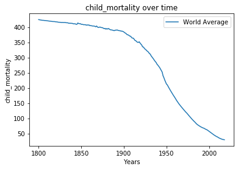

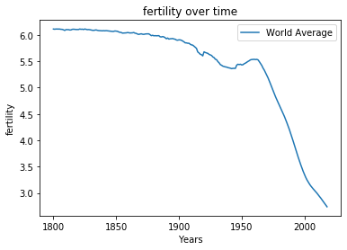

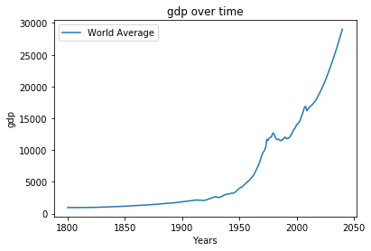

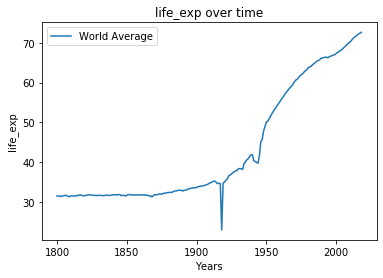

```python
# Trending all the 4 indices over the years

for i in df_y.columns[1:]:
    plt.plot(df_y['year'], df_y[i], label= "World Average")
    plt.xlabel('Years')
    plt.ylabel(i)
    plt.title('{} over time'.format(i))
    plt.legend()
    plt.show()
```

### 3.1 Observations

From the above graphs following observations can be made-  
1) Child Mortality has reduced from 425 in 1800 to 29 in 2018 probably due to progress in science and medicine.  
2) Fertility rate also has reduced from 6.1 births per woman to 2.7 births per woman. The ideal fertility rate is considered to be 2.1 per woman.  
3) GDP per capita has also increased from USD 947 to USD 18,241 from 1800 to 2018.  
4) The life expectancy has also increased from 31.5 to 72.6 from 1800 to 2018. There is however a dip in life expectancy in early 1900s which we will explore further.

```python
# Quantifying the averages in each index in 1800 and 2018.
df_y.query('year == 2018 | year == 1800')
```

|  | year | child_mortality | fertility | gdp | life_exp |
| --- | --- | --- | --- | --- | --- |
| 0 | 1800 | 424.543478 | 6.110707 | 947.782383 | 31.502717 |
| 218 | 2018 | 29.473443 | 2.737609 | 18241.502591 | 72.658152 |

**The 1918 Dip in Life Expectancy**  
The below code explores the dip in life expectancy in early 1900s. It can be seen that the dip happened in 1918. Historically this has been the year where massive deaths happened in World War 1 and famine plagued different parts of Asia and Africa. Life expectancy of several countries has dipped to single digits as can be seen in the code below.

```python
# Investigating the dip in life expectancy in early 1900s
df_y.query('year > 1910 & year <1930')

#The dip in life expectancy seems to be at 1918
# Exploring which countries experienced the maximum dip
my_df.query('year == 1918').sort_values(by='life_exp', ascending=True).head(10)
```

|  | year | country | child_mortality | fertility | gdp | life_exp |
| --- | --- | --- | --- | --- | --- | --- |
| 31216 | 1918 | Samoa | 209.0 | 6.98 | 2050.0 | 1.09 |
| 38224 | 1918 | Tonga | 176.0 | 6.51 | 969.0 | 5.87 |
| 6469 | 1918 | Cameroon | 443.0 | 5.54 | 1030.0 | 5.99 |
| 18952 | 1918 | Kenya | 489.0 | 6.91 | 1360.0 | 6.33 |
| 12601 | 1918 | Fiji | 481.0 | 5.45 | 1220.0 | 6.87 |
| 118 | 1918 | Afghanistan | 468.0 | 7.00 | 849.0 | 7.89 |
| 16543 | 1918 | India | 434.0 | 5.72 | 1160.0 | 8.12 |
| 28150 | 1918 | Pakistan | 518.0 | 6.59 | 1180.0 | 8.47 |
| 23989 | 1918 | Micronesia, Fed. Sts. | 207.0 | 6.02 | 613.0 | 8.55 |
| 14791 | 1918 | Guatemala | 485.0 | 6.15 | 1910.0 | 9.58 |

The histogram in the below code compares the life expectancy of the year 1918 with its adjacent years and it can be seen that almost all the countries suffered a lower number.

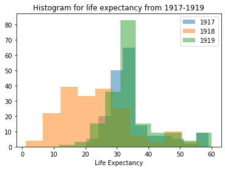

```python
# PLotting the life expectancy in year 1917,1918,1919 for comparison
plt.hist(my_df.query('year == 1917')['life_exp'],alpha= 0.5,label='1917' )
plt.hist(my_df.query('year == 1918')['life_exp'],alpha=0.5, label= '1918')
plt.hist(my_df.query('year == 1919')['life_exp'],alpha=0.5, label= '1919')
plt.legend()
plt.xlabel('Life Expectancy')
plt.title('Histogram for life expectancy from 1917-1919')
plt.show()
```

The below code is plotting boxplots for all the 4 indices for all the countries and comparing the year 1800 with year 2018.

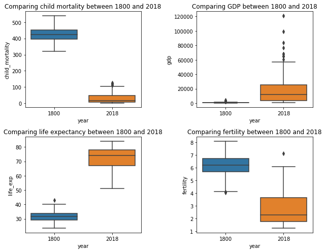

```python
plt.figure(figsize=(9,7))

# Making a 2x2 matrix for plots
plt.subplot(2,2,1)
sns.boxplot(x= my_df.query('year == 1800 | year == 2018')['year'], y =\
            my_df.query('year == 1800| year == 2018')['child_mortality'] )
plt.title('Comparing child mortality between 1800 and 2018')

plt.subplot(2,2,2)
sns.boxplot(x= my_df.query('year == 1800 | year == 2018')['year'], y =\
            my_df.query('year == 1800| year == 2018')['gdp'] )
plt.title('Comparing GDP between 1800 and 2018')

plt.subplot(2,2,3)
sns.boxplot(x= my_df.query('year == 1800 | year == 2018')['year'], y =\
            my_df.query('year == 1800| year == 2018')['life_exp'] )
plt.title('Comparing life expectancy between 1800 and 2018')

plt.subplot(2,2,4)
sns.boxplot(x= my_df.query('year == 1800 | year == 2018')['year'], y =\
            my_df.query('year == 1800| year == 2018')['fertility'] )
plt.title('Comparing fertility between 1800 and 2018')

plt.tight_layout()

plt.show()
```

### 3.2 Finding Correlations between Indices

Seaborn library was used to find coorelation between the 4 indices. Pearson's coefficient is also calculated to quantify the correlation.

**Observations**  
1) It can be seen that there is a **strong negative** correlation between **child mortality and life expectancy**.( Pearson's coefficient: -0.99). The underlying cause might be better healthcare facilities in those countries which lead to both higher life expectancy and lower child mortality.  
2) There is a **strong postive** correlation between **GDP and life expectancy** (coefficient: 0.96) which shows that richer countries enjoy longer life.  
3) **Child mortality and fertility** have **postive** correlation of 0.9. This could possibly be that parents have less kids if the child has higher chance of survival to adulthood. However, there might be other factors in play here.  
4) Higher GDP nations have less fertility rates (coefficient: -0.96).

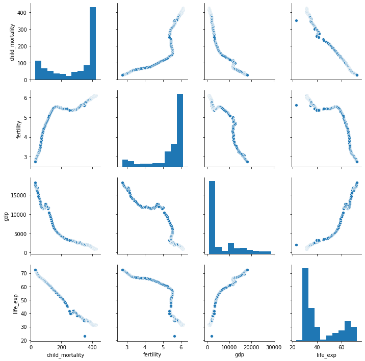

```python
# Visualizing the correlation between different indices
sns.pairplot(df_y.iloc[:,1:],)
```

```python
# Finding person's correlation coefficient
df_y.iloc[:,1:].corr(method= 'pearson')
```

|  | child_mortality | fertility | gdp | life_exp |
| --- | --- | --- | --- | --- |
| child_mortality | 1.000000 | 0.905109 | -0.950005 | -0.991915 |
| fertility | 0.905109 | 1.000000 | -0.963023 | -0.908923 |
| gdp | -0.950005 | -0.963023 | 1.000000 | 0.965007 |
| life_exp | -0.991915 | -0.908923 | 0.965007 | 1.000000 |

### 3.3 Biggest improvement in Indices

To find which countries had the biggest improvements over child mortality, GDP and life expectancy, we take the slope/ gradient of these indicators over 200 years.

We take the ratio of range (max -min) of these indicators and time period (2018-1800).

```python
# Maximum improvement in indicators
df_c =my_df.groupby(by='country')
df_grad= (df_c.max()- df_c.min())/ (2018-1800)

#Biggest improvement in child mortality in rate of change of child death
print(df_grad.sort_values(by='child_mortality', ascending= False).head(2)['child_mortality'], '\n')

#Biggest improvement in life_expectancy
print(df_grad.sort_values(by='life_exp', ascending= False).head(2)['life_exp'], '\n')

#Biggest improvement in gdp
print(df_grad.sort_values(by='gdp', ascending= False).head(2)['gdp'])
```

```
country
Philippines    3.348624
Barbados       3.075688
Name: child_mortality, dtype: float64

country
Tunisia    0.350917
Finland    0.339404
Name: life_exp, dtype: float64

country
Qatar                   830.045872
United Arab Emirates    811.935780
Name: gdp, dtype: float64
```

The below code is finding the min and max values for the above countries for each of those indicators.

```python
# Quantifying the improvement indicators
print('Child Mortality- max', my_df.query('country == "Philippines"')['child_mortality'].max())
print('Child Mortality- min',my_df.query('country == "Philippines"')['child_mortality'].min())

print('Life_exp- max',my_df.query('country == "Tunisia"')['life_exp'].max())
print('Life_exp- min', my_df.query('country == "Tunisia"')['life_exp'].min())

print('GDP- max',  my_df.query('country == "Qatar"')['gdp'].max())
print('GDP- min', my_df.query('country == "Qatar"')['gdp'].min())
```

```
Child Mortality- max 756.0
Child Mortality- min 26.0
Life_exp- max 78.0
Life_exp- min 1.5
GDP- max 182000.0
GDP- min 1050.0
```

We will plot line plots in Matplotlib for these countries that had shown most improvement and compare it with the rest of the world

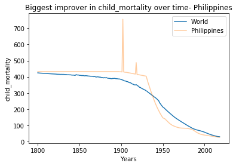

```python
# Plotting biggest improvements in child_mortality and comparing with the world

plt.plot(df_y['year'], df_y['child_mortality'], label= "World")

plt.plot(my_df[my_df['country']== 'Philippines'].iloc[:,0], my_df[my_df['country']=='Philippines']['child_mortality'],\
             label= 'Philippines', alpha= 0.4)

plt.xlabel('Years')
plt.ylabel('child_mortality')
plt.title('Biggest improver in {} over time- Philippines'.format('child_mortality'))
plt.legend()
plt.show()
```

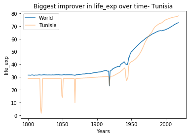

```python
# Plotting biggest improvements in child_mortality and comparing with the world
plt.plot(df_y['year'], df_y['life_exp'], label= "World")

plt.plot(my_df[my_df['country']== 'Tunisia'].iloc[:,0], my_df[my_df['country']=='Tunisia']['life_exp'],\
             label= 'Tunisia', alpha= 0.4)

plt.xlabel('Years')
plt.ylabel('life_exp')
plt.title('Biggest improver in {} over time- Tunisia'.format('life_exp'))
plt.legend()
plt.show()
```

### 3.4 Best country for each index in 2018

The best country in each indicator in 2018 was found and a line plot was plotted where each of these country was compared with USA, China and world in that category.

```python
# Finding the best countries for each indicator in 2018
my_df18= my_df.query('year == 2018')

#Country with lowest child mortality
print('\n Lowest child mortality')
print(my_df18[my_df18['child_mortality']== my_df18['child_mortality'].min()])
        #Finland

#Country with ideal fertility ~2.1
print('\n Ideal fertility ~2.1')
print(my_df18[(my_df18['fertility']>= 2.08) & (my_df18['fertility']<= 2.12) ])
        #Mexico

#Country with highest gdp/ capita
print('\n Highest gdp/ capita')
print(my_df18[my_df18['gdp']== my_df18['gdp'].max()])
        #Qatar

#Country with highest life expectancy
print('\n Highest life expectancy')
print(my_df18[my_df18['life_exp']== my_df18['life_exp'].max()])
```

```
 Lowest child mortality
       year  country  child_mortality  fertility      gdp  life_exp
12920  2018  Finland             1.95       1.78  40300.0      82.1

 Ideal fertility ~2.1
       year country  child_mortality  fertility      gdp  life_exp
23870  2018  Mexico             13.8       2.12  17300.0      76.8

 Highest gdp/ capita
       year country  child_mortality  fertility       gdp  life_exp
30440  2018   Qatar             7.98       1.87  121000.0      80.7

 Highest life expectancy
       year country  child_mortality  fertility      gdp  life_exp
18395  2018   Japan             2.76       1.48  39100.0      84.2
```

Matplotlib is used to plot line plots for Finland, Mexico, Qatar and Japan in each category where they were the best. This was then compared with performance of USA, China and world average.  
**Observations**  
1) **Finland** had the **lowest child mortality** rate in the world at 1.95 deaths/ thousand births. Its mortality rate is very similar to United States since 1900s. Historically China had a higher child mortality rate, however, after a big dip in 1960s it is converging with that of the USA and is lower than the world average.  
2) **Mexico** has close to **ideal fertility rate** (ideal is 2.1) of 2.12. Both China and Mexico have seen a huge drop in fertility rate in the 1960s and 1970s. Currently both China and USA have lower than ideal fertility rate.  
3) **Qatar has the highest per capita GDP** in the world at USD 121,000. Qatar saw a huge jump in the GDP/capita in early 1950s and continues to be significantly higher than USA and China.  
4) **Japan** has seen a dramatic rise in **life expectancy** since 1950s. Its current life expectancy is 84.2 and is much higher than both USA and China. China has also seen a dramatic rise in life expectancy since 1960s.

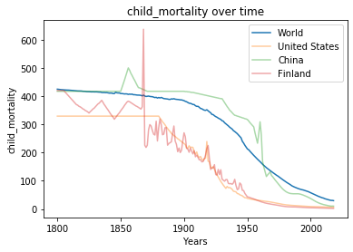

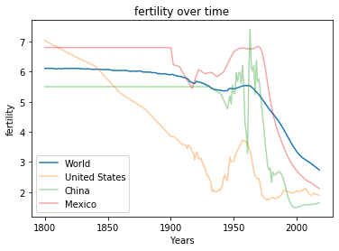

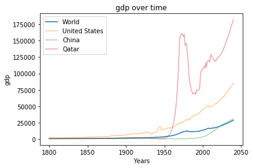

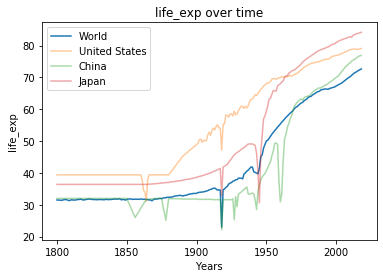

```python
# Comparing major economies with world averages

j=0

for i in df_y.columns[1:]:
    plt.plot(df_y['year'], df_y[i], label= "World")

    #plotting major economies
    plt.plot(my_df.query('country == "United States"').iloc[:,0], my_df.query('country == "United States"')[i],\
             label= "United States", alpha= 0.4)
    plt.plot(my_df.query('country == "China"').iloc[:,0], my_df.query('country == "China"')[i],\
             label= "China", alpha= 0.4)

    # plotting best country in each indicator
    best= ['Finland', 'Mexico','Qatar', 'Japan']

    plt.plot(my_df[my_df['country']== best[j]].iloc[:,0], my_df[my_df['country']==best[j]][i],\
             label= best[j], alpha= 0.4)
    j +=1

    plt.xlabel('Years')
    plt.ylabel(i)
    plt.title('{} over time'.format(i))
    plt.legend()
    plt.show()
```

### 3.5 GDP per capita comparison of major economies

Below plot shows the GDP of major world economies over time for comparison. It can be seen that for the foreseeable future it appears that USA will be maintaining its lead for GDP per capita and is enjoying a high growth since mid 2000s followed by Germany and United Kingdom.

After the slump in Russia from 1990s to early 2000s, its economy also seems to be recovering and growing. The European countries of UK, Germany, Italy and France and the Asian countries (China, Japan, India) are seeing steady growth in their GDPs too.

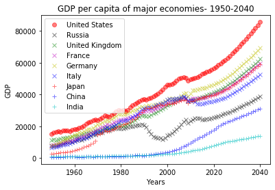

```python
econ= ['United States','Russia', 'United Kingdom', 'France', 'Germany','Italy', 'Japan','China',  'India']
col= ['ro', 'kx','gx','mx','yx','bx','r+','b+', 'c+' ]

#making a loop to plot all the countries from econ list and getting colors from col list
for i in range(len(econ)):
    plt.plot(my_df[(my_df['country']== econ[i]) & (my_df['year']>=1950)]['year'],\
         my_df[(my_df['country']== econ[i]) & (my_df['year']>=1950)]['gdp'], col[i], label= econ[i], alpha= 0.5)

plt.legend()
plt.xlabel('Years')
plt.ylabel('GDP')
plt.title('GDP per capita of major economies- 1950-2040')
plt.show()
```

## 4. Conclusion

From the time plots it is clear that child mortality rate is falling with time with sharp fall from 1900s onwards. Additionally, fertility rate also saw a sharp fall from 1950s while GDP per capita and life expectancy saw a rise since that period.

Moreover, there is a strong negative correlation between child mortality and life expectancy and between GDP per capita and fertility rates. Additionally, there is a strong positive correlation between GDP and life expectancy and between fertility and child mortality.

In 2018 Finland had the lowest child mortality whereas Qatar had the highest GDP per capita. Mexico had nearly ideal fertility rate while Japan has the highest life expectancy.

USA will probably be enjoying the highest per capita GDP growth till foreseeable future followed by Germany and United Kingdom.